# PEC 01 · Las ómicas

Nuria Garcia Martinez-Illescas

2024-11-03

## Objetivos

El objetivo del presente informe es investigar la relación entre la pérdida de masa muscular (denominada cachexia) y los datos metabolómicos de un conjunto de muestras biológicas.

## Materiales y métodos

Los datos analizados en este estudio fueron obtenidos de [esta URL](https://rest.xialab.ca/api/download/metaboanalyst/human_cachexia.csv) sobre un conjunto de muestras de orina de pacientes diagnosticados con cachexia y controles sanos.

Los datos fueron almacenados para su organización en la clase SummarizedExperiment con la finalidad de integrar los datos y metadatos de las muestras. Adiocionalmente se realizó un analisis de componentes principales (PCA) para analizar las variaciones entre grupos, y determinar los metabolitos específicos que estan asociados a la cachexia.

## Resultados

### Generación del contendor

```r
human_cachexia <- read.csv("human_cachexia.csv", row.names = 1)

human_cachexia$Muscle.loss <- as.factor(human_cachexia$Muscle.loss)
str(human_cachexia)
```

```
## 'data.frame':    77 obs. of  64 variables:
##  $ Muscle.loss                : Factor w/ 2 levels "cachexic","control": 1 1 1 1 1 1 1 1 1 1 ...
##  $ X1.6.Anhydro.beta.D.glucose: num  40.9 62.2 270.4 154.5 22.2 ...
##  $ X1.Methylnicotinamide      : num  65.4 340.4 64.7 53 73.7 ...
##  $ X2.Aminobutyrate           : num  18.7 24.3 12.2 172.4 15.6 ...
##  $ X2.Hydroxyisobutyrate      : num  26.1 41.7 65.4 74.4 83.9 ...
##  $ X2.Oxoglutarate            : num  71.5 67.4 23.8 1199.9 33.1 ...
##  $ X3.Aminoisobutyrate        : num  1480.3 116.8 14.3 555.6 29.7 ...
##  $ X3.Hydroxybutyrate         : num  56.83 43.82 5.64 175.91 76.71 ...
##  $ X3.Hydroxyisovalerate      : num  10.1 79.8 23.3 25 69.4 ...
##  $ X3.Indoxylsulfate          : num  567 369 665 412 166 ...
##  $ X4.Hydroxyphenylacetate    : num  120.3 432.7 292.9 214.9 97.5 ...
##  $ Acetate                    : num  126.5 212.7 314.2 37.3 407.5 ...
##  $ Acetone                    : num  9.49 11.82 4.44 206.44 44.26 ...
##  $ Adipate                    : num  38.1 327 131.6 144 15 ...
```

[output cut: 50 more lines]

El siguiente paso fue estructurar los datos para introducirlos en nuestro contenedor. Se crea la matriz de conteo con todos los datos metabolómicos, el objeto colData que contendrá la información de las muestras. Además de el metadata con la información del experimento. Para ello es necesario transponer los datos de los metabolitos, puesto que el contenedor SummarizedExperiment tiene una disposición tal que las columnas corresponden a las muestras y las filas a las medidas (en nuestro caso metabolitos). Generamos finalmente el objeto SummarizedExperiment con toda la información del experimento.

```r
counts <- as.matrix(human_cachexia[, -1])
counts <- t(counts)
colData <- DataFrame(Muscle.loss = human_cachexia$Muscle.loss)

metadata <- list(
  general_information = "Successfully passed sanity check!",
  samples = "Samples are not paired.",
  groups = "2 groups were detected in samples.",
  data_values = "All data values are numeric.",
  missing_values = "A total of 0 (0%) missing values were detected."
)

se <- SummarizedExperiment(assays=list(counts=counts), colData=colData,
                           metadata = metadata)
se
```

```
## class: SummarizedExperiment
## dim: 63 77
## metadata(5): general_information samples groups data_values
##   missing_values
## assays(1): counts
## rownames(63): X1.6.Anhydro.beta.D.glucose X1.Methylnicotinamide ...
##   pi.Methylhistidine tau.Methylhistidine
## rowData names(0):
## colnames(77): PIF_178 PIF_087 ... NETL_003_V1 NETL_003_V2
## colData names(1): Muscle.loss
```

```r
dimnames(se)
```

```
## [[1]]
##  [1] "X1.6.Anhydro.beta.D.glucose" "X1.Methylnicotinamide"
##  [3] "X2.Aminobutyrate"            "X2.Hydroxyisobutyrate"
##  [5] "X2.Oxoglutarate"             "X3.Aminoisobutyrate"
##  [7] "X3.Hydroxybutyrate"          "X3.Hydroxyisovalerate"
##  [9] "X3.Indoxylsulfate"           "X4.Hydroxyphenylacetate"
## [11] "Acetate"                     "Acetone"
## [13] "Adipate"                     "Alanine"
## [15] "Asparagine"                  "Betaine"
## [17] "Carnitine"                   "Citrate"
## [19] "Creatine"                    "Creatinine"
## [21] "Dimethylamine"               "Ethanolamine"
## [23] "Formate"                     "Fucose"
## [25] "Fumarate"                    "Glucose"
## [27] "Glutamine"                   "Glycine"
```

[output cut: 36 more lines]

```r
colData(se)
```

```
## DataFrame with 77 rows and 1 column
##              Muscle.loss
##                 <factor>
## PIF_178         cachexic
## PIF_087         cachexic
## PIF_090         cachexic
## NETL_005_V1     cachexic
## PIF_115         cachexic
## ...                  ...
## NETCR_019_V2     control
## NETL_012_V1      control
## NETL_012_V2      control
## NETL_003_V1      control
## NETL_003_V2      control
```

A partir de nuestro objeto **se** podemos obtener la matriz de conteos con las concentraciones de los metabolitos para cada muestra. Además podemos filtrar los datos de metabolitos por grupo de muestras así como ver las distribuciones de las medias entre los mismos y hacernos una idea si existen muchas diferencias en los niveles.

```r
counts <- assay(se)

mean_control <- rowMeans(counts[,se$Muscle.loss=="control"])
mean_cachexia <- rowMeans(counts[,se$Muscle.loss=="cachexic"])

mean_comparison <- data.frame(
  Media_Control = mean_control,
  Media_Cachexia = mean_cachexia
)
mean_comparison
```

```
##                             Media_Control Media_Cachexia
## X1.6.Anhydro.beta.D.glucose     69.505333     128.688936
## X1.Methylnicotinamide           73.155000      70.564255
## X2.Aminobutyrate                 9.528333      23.669149
## X2.Hydroxyisobutyrate           27.871000      43.237660
## X2.Oxoglutarate                 85.517333     183.110426
## X3.Aminoisobutyrate             39.911000     100.274681
## X3.Hydroxybutyrate               9.898667      29.260638
## X3.Hydroxyisovalerate           12.312667      27.606383
## X3.Indoxylsulfate              146.376333     265.157660
## X4.Hydroxyphenylacetate         99.798667     119.822553
## Acetate                         35.604667      85.632979
## Acetone                          8.420000      13.346383
## Adipate                          8.993333      34.817872
## Alanine                        157.584000     347.591064
## Asparagine                      41.749000      75.390851
## Betaine                         55.970333     112.252979
## Carnitine                       32.443667      64.622128
## Citrate                       1474.718667    2720.852766
## Creatine                        51.504333     174.913404
## Creatinine                    5619.174667   10722.140213
## Dimethylamine                  208.683333     453.580638
## Ethanolamine                   197.125333     326.772128
## Formate                         84.483333     187.564468
## Fucose                          57.444667     108.599149
## Fumarate                         4.552000      10.921915
## Glucose                        140.958000     827.218936
## Glutamine                      174.427333     391.410426
## Glycine                        585.149333    1069.377872
## Glycolate                      138.983667     219.269574
## Guanidoacetate                  68.739667      97.624255
## Hippurate                     1364.240333    2875.729574
## Histidine                      180.472333     364.232340
## Hypoxanthine                    51.714333      67.087021
## Isoleucine                       7.218000       9.660851
## Lactate                         65.748333     217.631915
## Leucine                         13.556667      31.261702
## Lysine                          89.229333     121.282340
## Methylamine                     11.360000      21.216383
## Methylguanidine                 12.128333      17.364681
```

[output cut: 9 more lines]

```
## Tartrate                        28.676000      47.234681
## Taurine                        320.522333     655.720000
## Threonine                       59.518667     118.233191
## Trigonelline                   130.687000     359.637660
## Trimethylamine.N.oxide         388.669000     820.340638
## Tryptophan                      41.833000      81.824043
## Tyrosine                        52.014000     100.742340
## Uracil                          32.493333      37.513617
## Valine                          20.132667      45.582553
## Xylose                          56.509333     129.289149
## cis.Aconitate                   91.724000     276.025532
## myo.Inositol                    62.641333     181.837660
## trans.Aconitate                 27.809333      48.814043
## pi.Methylhistidine             258.640000     441.553191
## tau.Methylhistidine             64.650333     105.667660
```

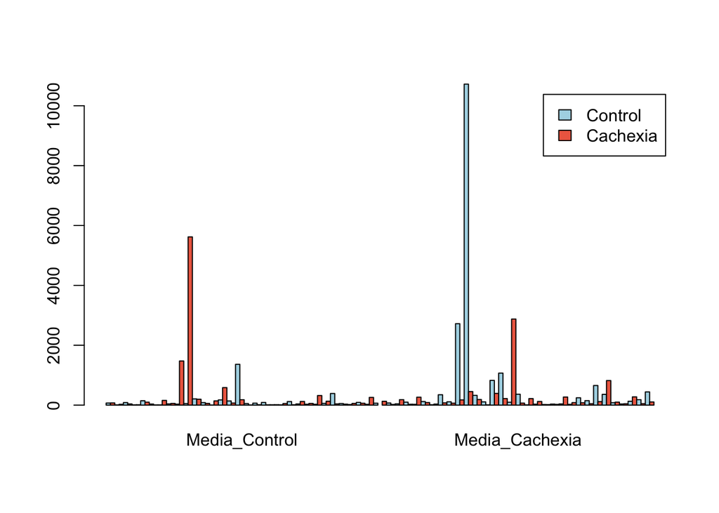

```r
barplot(as.matrix(mean_comparison),
        beside = TRUE,
        col = c("lightblue", "coral2"),
        legend = c("Control", "Cachexia"))
```

### Exploración de datos

Posteriormente, se llevó a cabo un análisis de componentes principales (PCA) para observar la variabilidad de los metabolitos entre los grupos. Para ello usamos prcomp() expluyendo la primera columna que contiene la información de pertenencia a un grupo (ya sea controles o cachexia).

```r
pca <- prcomp(human_cachexia[, -1])
sum_pca <- summary(pca)
sum_pca
```

```
## Importance of components:
##                              PC1       PC2       PC3       PC4       PC5
## Standard deviation     6851.7365 2622.8132 1.696e+03 1.357e+03 819.83955
## Proportion of Variance    0.7717    0.1131 4.728e-02 3.027e-02   0.01105
## Cumulative Proportion     0.7717    0.8848 9.321e-01 9.623e-01   0.97339
##                              PC6       PC7      PC8       PC9      PC10
## Standard deviation     695.64791 530.64795 487.0820 351.33316 309.39798
## Proportion of Variance   0.00795   0.00463   0.0039   0.00203   0.00157
## Cumulative Proportion    0.98134   0.98597   0.9899   0.99190   0.99347
##                             PC11      PC12      PC13      PC14      PC15
## Standard deviation     247.94190 226.25912 213.79022 192.05209 162.75532
## Proportion of Variance   0.00101   0.00084   0.00075   0.00061   0.00044
## Cumulative Proportion    0.99448   0.99533   0.99608   0.99668   0.99712
##                            PC16      PC17      PC18      PC19      PC20
## Standard deviation     155.7620 140.93059 138.48473 127.11181 120.82023
## Proportion of Variance   0.0004   0.00033   0.00032   0.00027   0.00024
## Cumulative Proportion    0.9975   0.99784   0.99816   0.99842   0.99866
##                             PC21      PC22     PC23     PC24     PC25     PC26
## Standard deviation     119.07949 103.65002 99.67204 87.69537 81.35187 69.02493
## Proportion of Variance   0.00023   0.00018  0.00016  0.00013  0.00011  0.00008
## Cumulative Proportion    0.99890   0.99907  0.99924  0.99936  0.99947  0.99955
##                            PC27     PC28     PC29     PC30     PC31     PC32
## Standard deviation     67.48679 63.70125 57.52296 50.81631 46.91029 46.28588
## Proportion of Variance  0.00007  0.00007  0.00005  0.00004  0.00004  0.00004
## Cumulative Proportion   0.99963  0.99969  0.99975  0.99979  0.99983  0.99986
##                            PC33     PC34     PC35     PC36     PC37     PC38
## Standard deviation     40.85547 36.52620 31.29715 28.31245 26.01032 22.69139
## Proportion of Variance  0.00003  0.00002  0.00002  0.00001  0.00001  0.00001
## Cumulative Proportion   0.99989  0.99991  0.99993  0.99994  0.99995  0.99996
##                            PC39     PC40     PC41  PC42  PC43 PC44  PC45  PC46
## Standard deviation     21.72509 20.18788 17.62542 15.78 15.54 13.6 11.58 10.52
## Proportion of Variance  0.00001  0.00001  0.00001  0.00  0.00  0.0  0.00  0.00
## Cumulative Proportion   0.99997  0.99997  0.99998  1.00  1.00  1.0  1.00  1.00
##                         PC47  PC48 PC49 PC50  PC51  PC52  PC53  PC54  PC55
## Standard deviation     9.081 8.383 7.52 6.72 6.077 4.932 4.047 3.618 3.272
## Proportion of Variance 0.000 0.000 0.00 0.00 0.000 0.000 0.000 0.000 0.000
## Cumulative Proportion  1.000 1.000 1.00 1.00 1.000 1.000 1.000 1.000 1.000
##                         PC56  PC57  PC58  PC59  PC60  PC61   PC62   PC63
## Standard deviation     3.111 2.921 2.563 2.194 1.676 1.419 0.8066 0.3846
## Proportion of Variance 0.000 0.000 0.000 0.000 0.000 0.000 0.0000 0.0000
## Cumulative Proportion  1.000 1.000 1.000 1.000 1.000 1.000 1.0000 1.0000
```

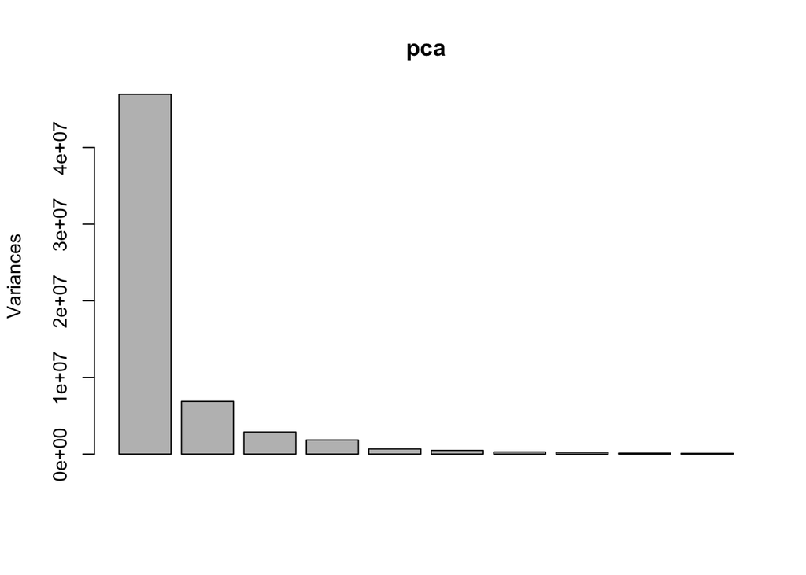

```r
plot(pca)
```

El resumen del PCA indica que los dos primeros componentes nos permiten explicar una proporción elevada de la varianza total por lo que pueden usarse para la diferenciación entre grupos. De hecho se visualiza la propoción de varianza explicada con fvix_eig() lo que nos permitió determinar que los cuatro primeros componentes explican casi la totalidad de la variabilidad.

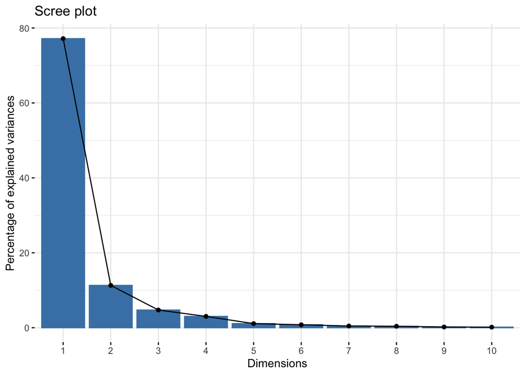

```r
fviz_eig(pca)
```

Posteriormente, se genera el gráfico para mostrar los resultados del PCA en las dos componentes principales coloreando cada grupo de un color:

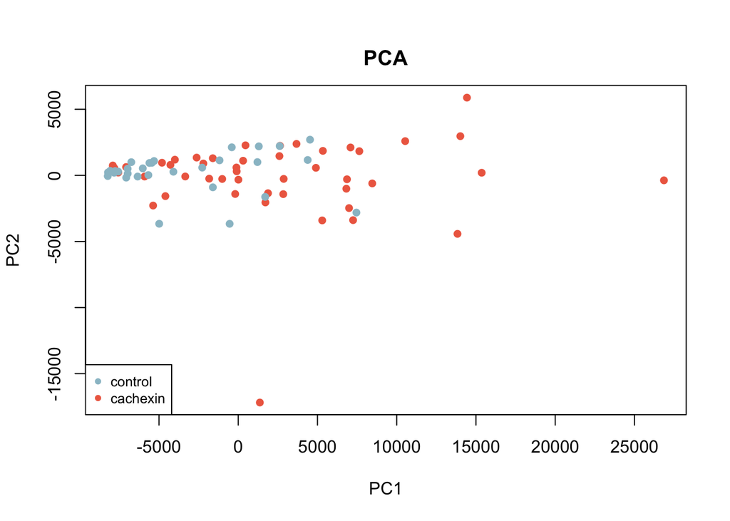

```r
plot(pca$x[,1:2], col=ifelse(human_cachexia$Muscle.loss == "control", "lightblue3", "coral2"),
     pch =16,
     xlab="PC1", ylab="PC2")
legend("bottomleft", pch=16, col=c("lightblue3", "coral2"),
       cex=0.8, legend = c("control", "cachexin"))
title(main="PCA", line=1)
```

No observamos un patrón claro que separe nuestros dos grupos en poblaciones diferenciales.

Para profundizar más en nuestro análisis y visto que en la gráfica que se generó con las medias entre grupos, parece existir variaciones en algunos metabolitos concretos evaluamos la contribución de las variables a los componentes principales:

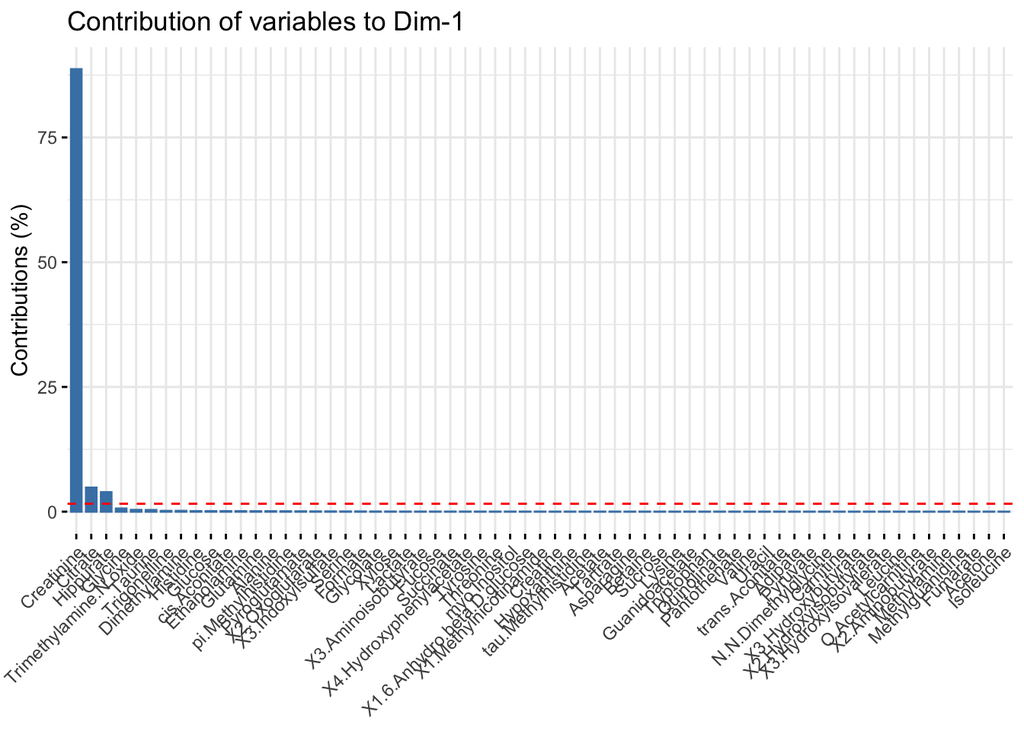

```r
fviz_contrib(pca, choice = "var")
```

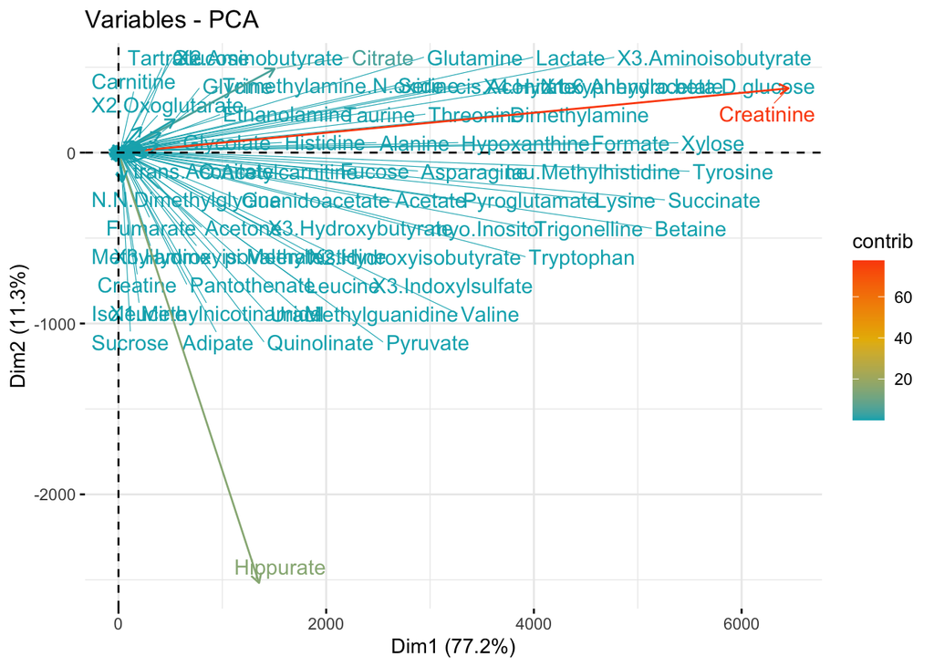

```r
fviz_pca_var(pca,
             col.var = "contrib",
             gradient.cols=c("#00AFBB", "#E7B800", "#FC4E07"),
             repel =TRUE)
```

## Discusión y conclusiones

Este análisis no ha permitido obtener una conclusión definitiva sobre los metabolitos específicos asociados a la pérdida de masa muscular. Sin embargo, se identificaron tres metabolitos con una influencia significativa en la distribución de los componentes principales, lo que sugiere que podrían ser biomarcadores prometedores para esta condición.

Para validar estos hallazgos, es fundamental realizar una serie de verificaciones iniciales. Primero, se debe revisar exhaustivamente los datos en busca de valores atípicos, ya que su presencia podría afectar la separación entre componentes y distorsionar los resultados del análisis basado en medias. Si los valores atípicos son descartados y las diferencias entre los niveles de estos metabolitos persisten, se recomienda un análisis más detallado enfocado en los componentes principales usando un conjunto reducido de metabolitos. Se podrían excluir aquellos metabolitos con poca o nula contribución en el análisis previo, y examinando si existe una correlación significativa entre los niveles de los metabolitos restantes y la presencia de debilidad muscular.

## Repositorio de Github

https://github.com/nugmi/Garcia-MartinezIllescas-Nuria-PEC1